# Avance Proyecto: Análisis ECU 911

Grupo 3: Anthony Perez, Franco Quezada, Ricardo Rios

2026-01-11

# 1. Introducción y Limpieza de Datos

El objetivo de este avance es procesar los datos de llamadas de emergencia del ECU 911 (Noviembre 2025) para parametrizar el modelo de simulación.

Se realizó la limpieza del dataset original:

- Se estandarizaron los nombres de columnas.
- Se formatearon las fechas.

**Nota:** Dado que la base pública original carecía de hora específica, se simuló la hora de llegada para cumplir con los requisitos de análisis temporal.

# 2. Análisis Visual (Gráficos)

A continuación se presentan los patrones de comportamiento de las emergencias, basados en las imágenes generadas en la carpeta `/figures`.

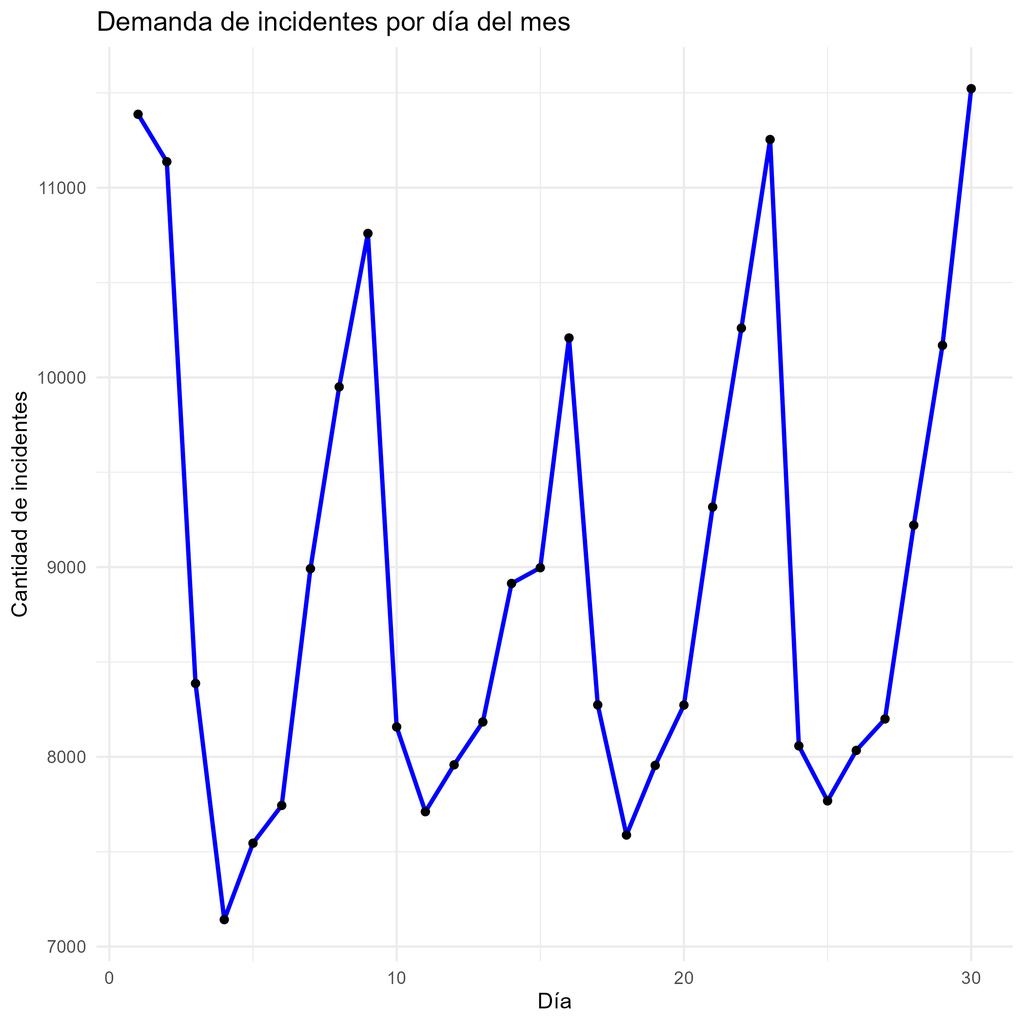

## 2.2 Distribución por Tipo de Servicio

Frecuencia de incidentes según la categoría principal (Salud, Policía, etc.).

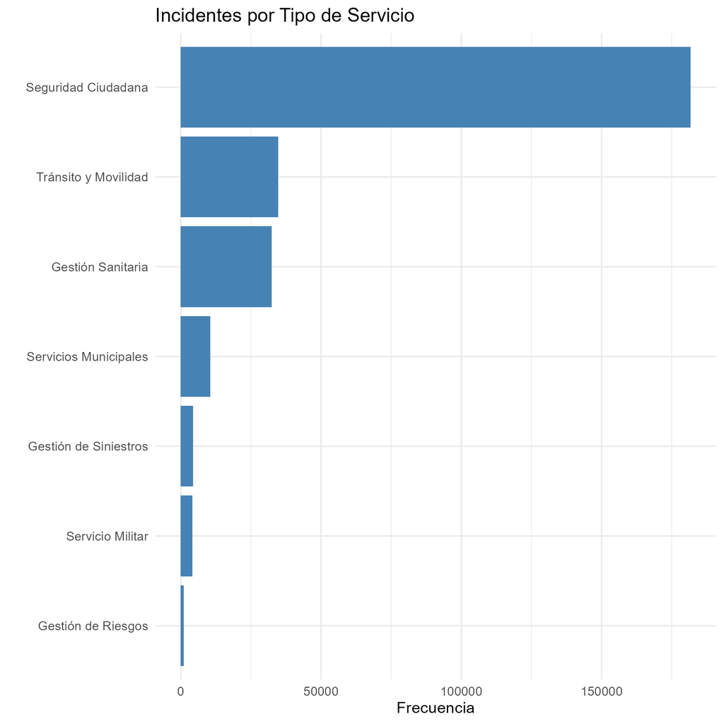

## 2.3 Top 10 Subtipos de Emergencia

Los incidentes específicos más frecuentes.

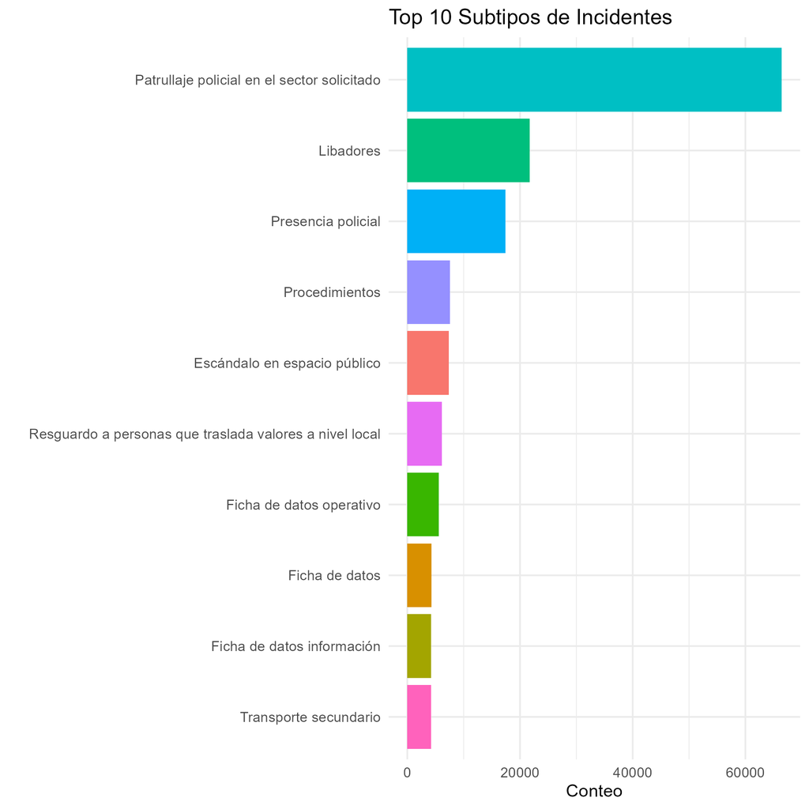